# SF3B1 iCLIP analysis

- Show All Code
- Hide All Code
- View Source

Binding site coverage profiles

Author

Affiliation

Dr. Mirko Brueggemann

Buchman Institute for Molecular Life Sciences

Published

September 19, 2023

# 1 Analysis Description

Compute iCLIP meta profiles around genomic landmarks. In total four libraries are used and compared: SF3B1-WT, SF3B1-MUT, U2AF2-WT, SF3B1-WT-eCLIP (all in K562). As genomic landmarks, annotated splice sites and predicted branchpoints are used.

# 2 Load libraries

```r
library(readr)
library(circlize)
library(patchwork)
library(ggsci)
library(ggnewscale)
library(knitr)
library(grid)
library(gridGraphics)
library(gridExtra)
library(scales)
library(reshape2)
library(ggplot2)
library(rtracklayer)
library(GenomicFeatures)
library(GenomicAlignments)
library(viridis)
library(tibble)
library(dplyr)
library(tidyr)
library(ComplexHeatmap)
library(kableExtra)
library(GenomicRanges)
library(BindingSiteFinder)
library(ggnewscale)
library(ggVennDiagram)
library(branchpointer)
library(BSgenome.Hsapiens.UCSC.hg38)
```

```r
source("../styles.R")
source("../helper.R")
```

# 3 Data preparation

For all comparisons the iCLIP signal is shown as the mean of means (mean of replicates and mean over respective ranges). No direct correction for library size was computed, since all replicates in the SF3B1 dataset were downsampled to the smallest sample. Thus profiles of the SF3B1 MUT and WT conditions can be compared directly. This is not possible for the U2AF2 or SF3B1-eCLIP dataset, which can only be evaluated from a positional point of view. In all profiles rows with only zeros (no iCLIP crosslinks) were removed.

```r
load("/Users/mirko/Projects/Annotations/human/gencode_36/filtered/gencode_v36_filtered.rda")
anno.db = loadDb("/Users/mirko/Projects/Annotations/human/gencode_36/filtered/gencode_v36_filtered.sqlite")
gns = genes(anno.db)
idx = match(gns$gene_id, anno$gene_id)
elementMetadata(gns) = cbind(elementMetadata(gns), elementMetadata(anno)[idx,])
```

```r
rngEnd = readRDS("../01_splicingMaps/data/rngEnd.rds")
# Load clip data SF3B1 WT
clipFilesWt = "/Users/mirko/Projects/sf3b1/01_data_subsamp/wt/cov/replicate"
clipFiles = c(clipFilesWt)
clipFiles = list.files(clipFiles, pattern = ".bw$", full.names = TRUE)
clipFilesP = clipFiles[grep(clipFiles, pattern = "Plus")]
clipFilesM = clipFiles[grep(clipFiles, pattern = "Minus")]
# Organize clip data in dataframe
colData = data.frame(
  id = 1:3,
  condition = factor(c("WT", "WT", "WT")),
  clPlus = clipFilesP,
  clMinus = clipFilesM)
bdsSF3B1_WT = BSFDataSetFromBigWig(ranges = rngEnd, meta = colData)

# Load clip data SF3B1 MUT
clipFilesMut = "/Users/mirko/Projects/sf3b1/01_data_subsamp/mut/cov/replicate"
clipFiles = c(clipFilesMut)
clipFiles = list.files(clipFiles, pattern = ".bw$", full.names = TRUE)
clipFilesP = clipFiles[grep(clipFiles, pattern = "Plus")]
clipFilesM = clipFiles[grep(clipFiles, pattern = "Minus")]
# Organize clip data in dataframe
colData = data.frame(
  id = 1:2,
  condition = factor(c("MUT", "MUT")),
  clPlus = clipFilesP,
  clMinus = clipFilesM)
bdsSF3B1_MUT = BSFDataSetFromBigWig(ranges = rngEnd, meta = colData)

# Load clip data U2AF65 WT
clipFilesWt = "/Users/mirko/Projects/BindingSiteStrength/01_data/05_U2AF65_cellLines/K562/cov/replicates/"
clipFiles = c(clipFilesWt)
clipFiles = list.files(clipFiles, pattern = ".bw$", full.names = TRUE)
clipFilesP = clipFiles[grep(clipFiles, pattern = "plus")]
clipFilesM = clipFiles[grep(clipFiles, pattern = "minus")]
# Organize clip data in dataframe
colData = data.frame(
  id = 1:4,
  condition = factor(rep("WT",4)),
  clPlus = clipFilesP,
  clMinus = clipFilesM)
# creating objects and importing clip siganl
bdsU2AF2_WT = BSFDataSetFromBigWig(ranges = rngEnd, meta = colData)

# Load eclip data SF3B1 WT
clipFilesWt = "/Users/mirko/Projects/sf3b1/04_eCLIP/sf3b1/"
clipFiles = c(clipFilesWt)
clipFiles = list.files(clipFiles, pattern = ".bw$", full.names = TRUE)
clipFilesP = clipFiles[grep(clipFiles, pattern = "plus")]
clipFilesM = clipFiles[grep(clipFiles, pattern = "minus")]
# Organize clip data in dataframe
colData = data.frame(
  id = 1:2,
  condition = factor(rep("WT",2)),
  clPlus = clipFilesP,
  clMinus = clipFilesM)
# creating objects and importing clip siganl
bdsSF3B1_ECLIP = BSFDataSetFromBigWig(ranges = rngEnd, meta = colData)

clipData = list(bdsSF3B1_WT = bdsSF3B1_WT,
                bdsSF3B1_MUT = bdsSF3B1_MUT,
                bdsU2AF2_WT = bdsU2AF2_WT,
                bdsSF3B1_ECLIP = bdsSF3B1_ECLIP)
```

## 3.1 Splice sites

```r
# ------------------------------------------------------------------------------
# get all introns from annotation
# ------------------------------------------------------------------------------
intrns = intronsByTranscript(anno.db) %>% unlist()
exn = exons(anno.db, use.names = TRUE)

# ------------------------------------------------------------------------------
# match 3'SS
# ------------------------------------------------------------------------------
# -> note:  additional matching step with positions from introns is needed to have
#           exon_ids for each splice sites, which allows machting with branchpoint
#           prediction later on
exn3pos = flank(unique(resize(exn, fix = "start", width = 1)), width = 1, start = TRUE)
int3pos = unique(resize(intrns, fix = "end", width = 1))
ss3Anno = subsetByOverlaps(exn3pos, int3pos)

# ------------------------------------------------------------------------------
# match 5'SS
# ------------------------------------------------------------------------------
exn5pos = flank(unique(resize(exn, fix = "end", width = 1)), width = 1, start = FALSE)
int5pos = unique(resize(intrns, fix = "start", width = 1))
ss5Anno = subsetByOverlaps(exn5pos, int5pos)
```

Annotated splice sites were extracted as all unique start/ end positions from exons in the GENCODE v36 annotation. In total this resulted in 253,512 3’SS and 257,261 5’SS. Please note that the number of 3’/ 5’ splice sites is not identical, since multiple 3’SS can relate to the same 5’SS and vice versa.

## 3.2 Branchpoint predictions

```r
pred = readRDS("./data/pred.rds")
names(pred) = 1:length(pred)

predSelAll = pred %>%
  as.data.frame() %>%
  group_by(exon_id) %>%
  filter(branchpoint_prob == max(branchpoint_prob))

predSel = pred %>%
  as.data.frame() %>%
  group_by(exon_id) %>%
  filter(branchpoint_prob > 0.52) %>%
  mutate(nBps = n()) %>%
  filter(branchpoint_prob == max(branchpoint_prob))

bpPred = GRanges(seqnames = predSel$seqnames,
                 ranges = IRanges(start = predSel$test_site, width = 1),
                 strand = predSel$strand,
                 gene_id = predSel$gene_id,
                 gene_type = predSel$gene_type,
                 exon_id = predSel$exon_id,
                 to_3prime_point = predSel$to_3prime_point,
                 to_5prime_point = predSel$to_5prime_point,
                 ppt_run_length = predSel$ppt_run_length,
                 U2_binding_energy = predSel$U2_binding_energy,
                 branchpoint_prob = predSel$branchpoint_prob,
                 nBps = predSel$nBps
                 )
```

## 3.3 Overlaps

To achieve comparability between the two splice site and the branchpoint prediction set, we reduced each set to the union of all three, using the `exon_id` as matching identifier. This results in a set of 93.679 exons, represented by a single 3’SS, 5’SS and branchpoint.

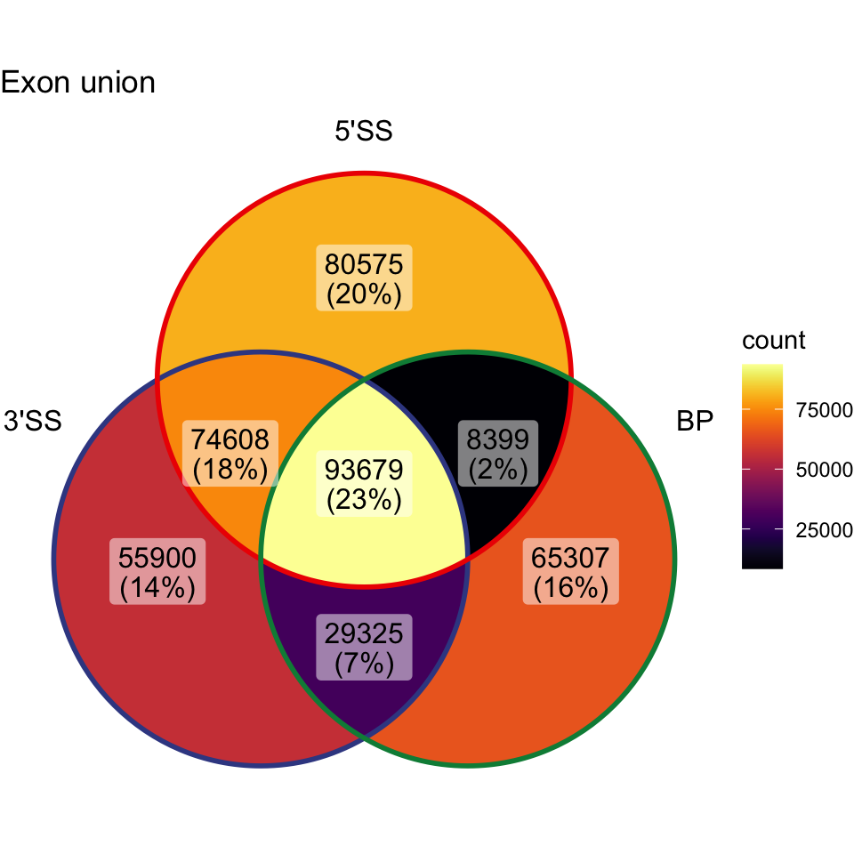

Intersection of annotated splice sites and predicted branchpoints

```r
l = list(
    spliceSites3 = unique(names(ss3Anno)),
    spliceSites5 = unique(names(ss5Anno)),
    branchpoints = bpPred$exon_id)
exnIntersectionIDs = Reduce(intersect, l)
ggVennDiagram(l, category.names = c("3'SS", "5'SS", "BP")) +
    labs(title = "Exon union") +
    scale_fill_viridis(option = "B") +
    scale_color_aaas()
```

# 4 Coverage profiles at landmarks

Meta profiles of SF3B1 WT and MUT with additional eCLIP of SF3B1 and iCLIP of U2AF2 confirmes the double-peak binding pattern of SF3B1.

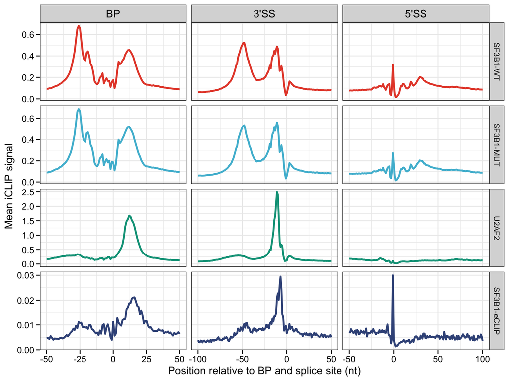

Coverage profiles

```r
makeDfPlotAll <- function(x, w, name, rngSs3, rngSs5, rngBp) {
  # set frame
  f3ss = rngSs3 + w
  f5ss = rngSs5 + w
  fbp = rngBp + w

  # calc 3'ss
  currObj = setRanges(x, f3ss)
  currCov = coverageOverRanges(currObj, returnOptions = "merge_all_replicates", method = "mean")
  currCov = currCov[rowSums(currCov) > 0,] # This removes rows with all zeros !
  # sum up coverage
  df1Cov = data.frame(pos = -w:w, mean = colMeans(currCov), type = "3'SS", data = name)

  # calc 5'ss
  currObj = setRanges(x, f5ss)
  currCov = coverageOverRanges(currObj, returnOptions = "merge_all_replicates", method = "mean")
  currCov = currCov[rowSums(currCov) > 0,] # This removes rows with all zeros !
  # sum up coverage
  df2Cov = data.frame(pos = -w:w, mean = colMeans(currCov), type = "5'SS", data = name)

  # calc bp
  currObj = setRanges(x, fbp)
  currCov = coverageOverRanges(currObj, returnOptions = "merge_all_replicates", method = "mean")
  currCov = currCov[rowSums(currCov) > 0,] # This removes rows with all zeros !
  # sum up coverage
  df3Cov = data.frame(pos = -w:w, mean = colMeans(currCov), type = "BP", data = name)

  # make return
  dfCov = rbind(df1Cov, df2Cov, df3Cov)
  d = list(dfCov = dfCov)
  return(d)
}

ss3Intersect = ss3Anno[names(ss3Anno) %in% exnIntersectionIDs]
ss5Intersect = ss5Anno[names(ss5Anno) %in% exnIntersectionIDs]
bpIntersect = bpPred[bpPred$exon_id %in% exnIntersectionIDs]

d1 = makeDfPlotAll(x = clipData$bdsSF3B1_WT, w = 100, name = "SF3B1-WT", rngSs3 = ss3Intersect, rngSs5 = ss5Intersect, rngBp = bpIntersect)
d2 = makeDfPlotAll(x = clipData$bdsSF3B1_MUT, w = 100, name = "SF3B1-MUT", rngSs3 = ss3Intersect, rngSs5 = ss5Intersect, rngBp = bpIntersect)
d3 = makeDfPlotAll(x = clipData$bdsU2AF2_WT, w = 100, name = "U2AF2", rngSs3 = ss3Intersect, rngSs5 = ss5Intersect, rngBp = bpIntersect)
d4 = makeDfPlotAll(x = clipData$bdsSF3B1_ECLIP, w = 100, name = "SF3B1-eCLIP", rngSs3 = ss3Intersect, rngSs5 = ss5Intersect, rngBp = bpIntersect)

dfCov = rbind(d1$dfCov,d2$dfCov,d3$dfCov,d4$dfCov)
dfCov$type = factor(dfCov$type, levels = c("BP", "3'SS", "5'SS"))
dfCov$data = factor(dfCov$data, levels = c("SF3B1-WT", "SF3B1-MUT", "U2AF2", "SF3B1-eCLIP"))

dfCov1 = dfCov %>% filter(pos %in% c(-100:50) & type == "3'SS" | pos %in% c(-50:100) & type == "5'SS" | pos %in% c(-50:50) & type == "BP")


ggplot(dfCov1, aes(x = pos, y = mean, color = data)) +
    geom_line(size = 1) +
    facet_grid(data~type, scales = "free") +
    theme_nice() +
    theme(legend.position = "none") +
    scale_color_npg() +
    labs(
        x = "Position relative to BP and splice site (nt)",
        y = "Mean iCLIP signal"
    )
```

## 4.1 Additional details

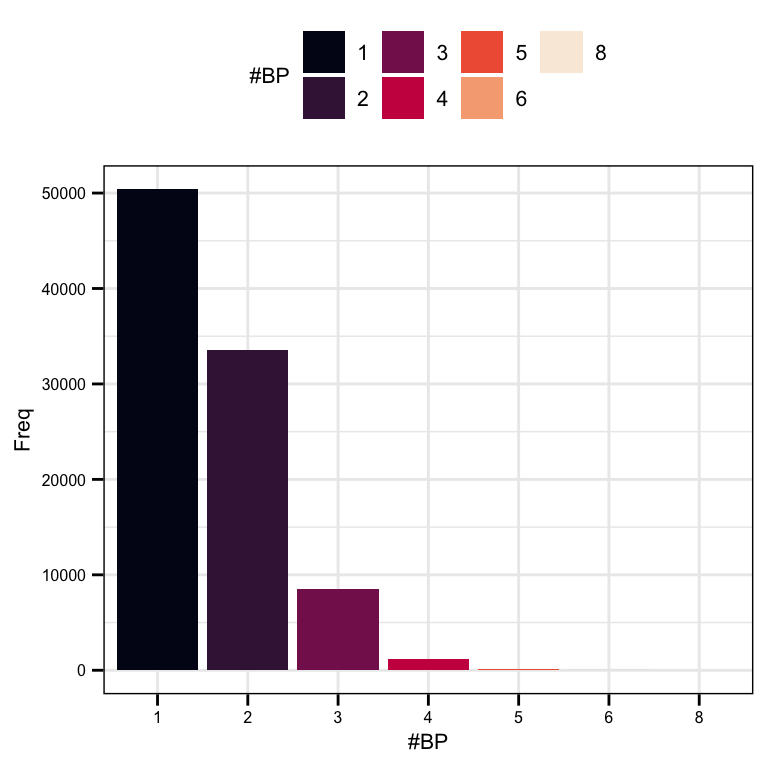

Frequency of multiple branchpoint predicitons per region

```r
bpIntersect = bpPred[bpPred$exon_id %in% exnIntersectionIDs]
bpIntersect$nBps2 = ifelse(bpIntersect$nBps > 4, 4, bpIntersect$nBps)

df = bpIntersect$nBps %>%
  table() %>%
  as.data.frame() %>%
  rename('#BP' = '.')

ggplot(df, aes(x = `#BP`, y = Freq, fill = `#BP`)) +
  geom_col(position = "dodge") +
  scale_fill_viridis(option = "rocket", discrete = TRUE) +
  theme_pub() +
  theme(legend.position = "top")
```

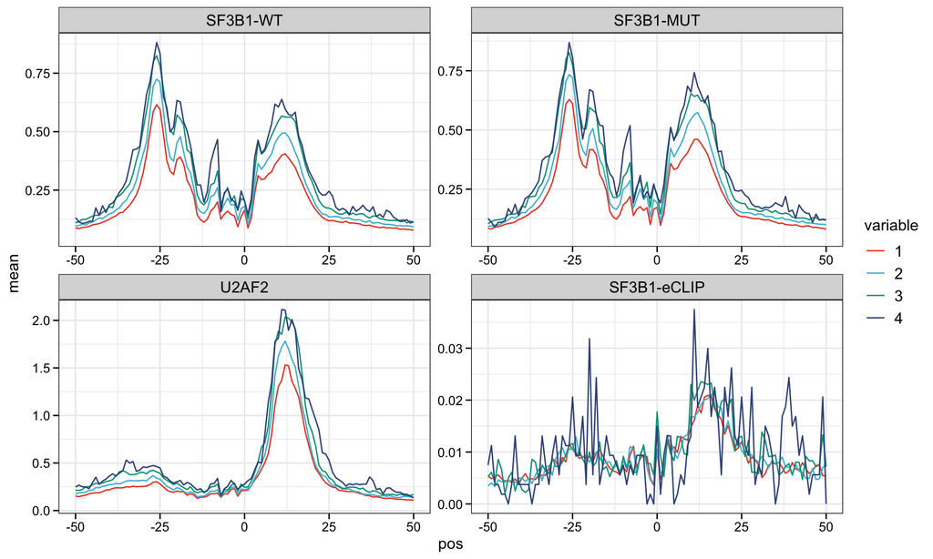

Coverage profiles split by the number of significant branchpoint predictions.

```r
makeDfPlotAll <- function(x, w, name, set) {
  # set frame
  f3ss = set + w
  # calc bp
  currObj = setRanges(x, f3ss)
  currCov = coverageOverRanges(currObj, returnOptions = "merge_all_replicates", method = "mean")
  currCov = currCov[rowSums(currCov) > 0,] # This removes rows with all zeros !
  df1Cov = data.frame(pos = -w:w, mean = colMeans(currCov), type = "3'SS", data = name)
  # make return
  dfCov = rbind(df1Cov)
  d = list(dfCov = dfCov)
  return(d)
}

bpIntersect = bpPred[bpPred$exon_id %in% exnIntersectionIDs]
bpIntersect$nBps2 = ifelse(bpIntersect$nBps > 4, 4, bpIntersect$nBps)
bpList = split(bpIntersect, bpIntersect$nBps2)

d = lapply(bpList, function(x){
  d1 = makeDfPlotAll(x = clipData$bdsSF3B1_WT, w = 100, name = "SF3B1-WT", set = x)
  d2 = makeDfPlotAll(x = clipData$bdsSF3B1_MUT, w = 100, name = "SF3B1-MUT", set = x)
  d3 = makeDfPlotAll(x = clipData$bdsU2AF2_WT, w = 100, name = "U2AF2", set = x)
  d4 = makeDfPlotAll(x = clipData$bdsSF3B1_ECLIP, w = 100, name = "SF3B1-eCLIP", set = x)
  dfCov = rbind(d1$dfCov,d2$dfCov,d3$dfCov,d4$dfCov)
  dfCov$type = factor(dfCov$type, levels = c("3'SS", "5'SS"))
  dfCov$data = factor(dfCov$data, levels = c("SF3B1-WT", "SF3B1-MUT", "U2AF2", "SF3B1-eCLIP"))
  return(dfCov)
})
df = dplyr::bind_rows(d, .id = "variable")

ggplot(df, aes(x = pos, y = mean, color = variable)) +
  geom_line() +
  facet_wrap(~data, scales = "free", ncol = 2) +
  theme_nice() +
  theme(legend.position = "right") +
  scale_color_npg() +
  xlim(-50,50)
```

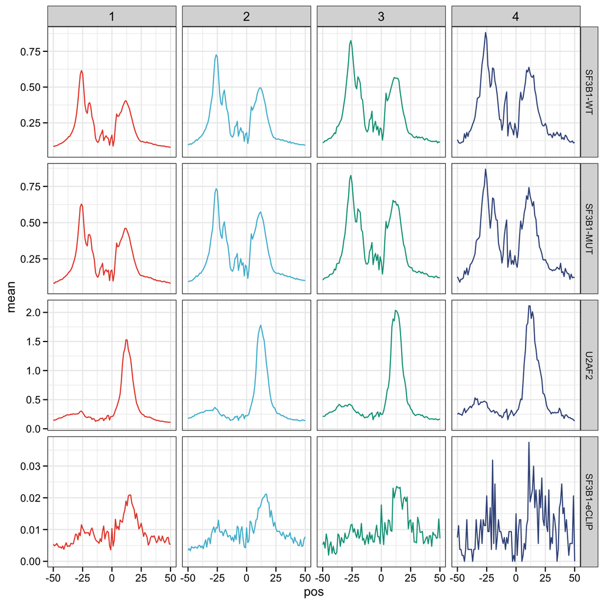

Coverage profiles split by the number of significant branchpoint predictions.

```r
ggplot(df, aes(x = pos, y = mean, color = variable)) +
  geom_line() +
  facet_grid(data~variable, scales = "free") +
  theme_nice() +
  theme(legend.position = "none") +
  scale_color_npg() +
  xlim(-50, 50)
```

# 5 Coverage profiles at landmarks WT vs MUT

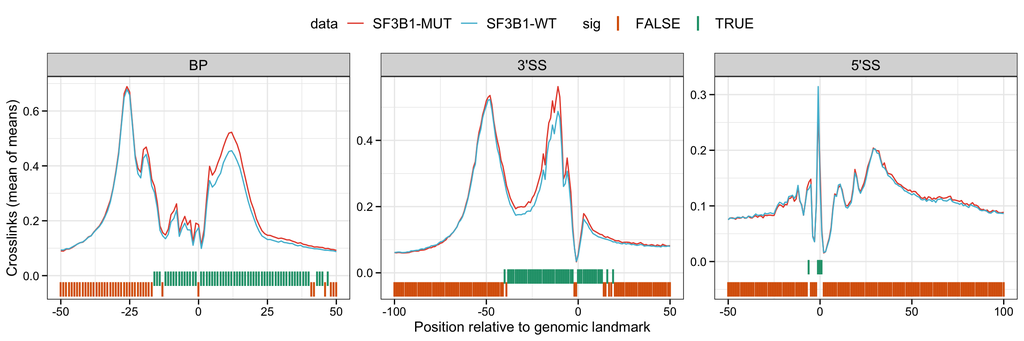

Coverage profiles comparisson of SF3B1 WT and MUT signal

```r
d = makeCoverageAndCompare(x = clipData$bdsSF3B1_WT, y = clipData$bdsSF3B1_MUT,
                   Xname = "SF3B1-WT", Yname = "SF3B1-MUT", w = 100,
                   rngSs3 = ss3Intersect, rngSs5 = ss5Intersect, rngBp = bpIntersect)
d$dfTest$sig = ifelse(d$dfTest$pAdj < 0.01, TRUE, FALSE)
d$dfTest$type = factor(d$dfTest$type, levels = c("BP", "3'SS", "5'SS"))
d$dfCov$type = factor(d$dfCov$type, levels = c("BP", "3'SS", "5'SS"))

dfCov1 = d$dfCov %>% filter(pos %in% c(-100:50) & type == "3'SS" | pos %in% c(-50:100) & type == "5'SS" | pos %in% c(-50:50) & type == "BP")
dfTest1 = d$dfTest %>% filter(pos %in% c(-100:50) & type == "3'SS" | pos %in% c(-50:100) & type == "5'SS" | pos %in% c(-50:50) & type == "BP")

ggplot() +
    geom_line(data = dfCov1, aes(x = pos, y = mean, color = data)) +
    scale_color_npg() +
    ggnewscale::new_scale_color() +
    geom_point(data = subset(dfTest1, sig == FALSE), aes(x = pos, y = -.05, color = sig), size = 4, shape = 73, stroke = 3) +
    geom_point(data = subset(dfTest1, sig == TRUE), aes(x = pos, y = -.01, color = sig), size = 4, shape = 73, stroke = 3) +
    scale_color_brewer(palette = "Dark2", direction = -1) +
    facet_wrap(~type, scales = "free") +
    theme_nice() +
    theme(legend.position = "top") +
    labs(
        x = "Position relative to genomic landmark",
        y = "Crosslinks (mean of means)"
    )
```

## 5.1 Additional details

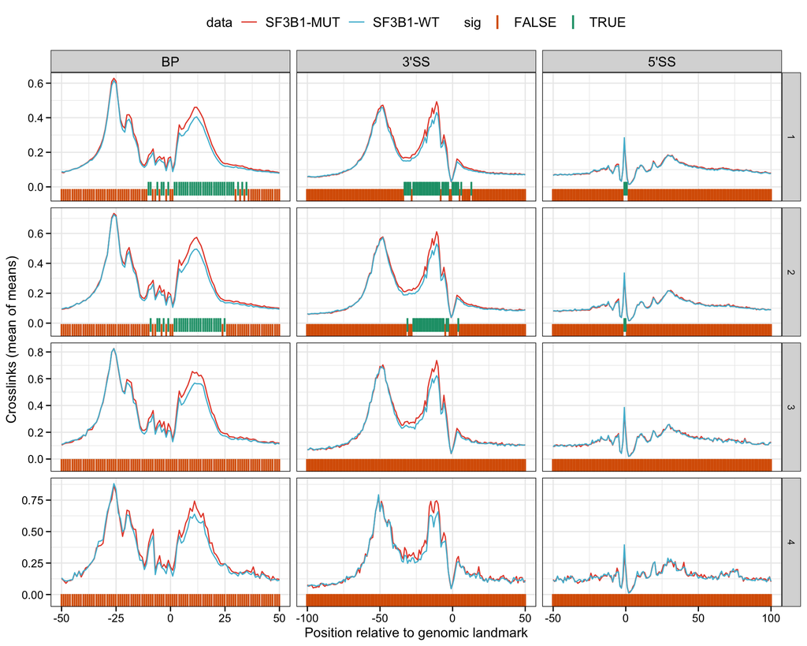

Coverage profiles comparisson of SF3B1 WT and MUT signal, split by the number of significant branchpoint predictions.

```r
bpIntersect = bpPred[bpPred$exon_id %in% exnIntersectionIDs]
bpIntersect$nBps2 = ifelse(bpIntersect$nBps > 4, 4, bpIntersect$nBps)
bpList = split(bpIntersect, bpIntersect$nBps2)

d = lapply(bpList, function(x){
  currExns = x$exon_id
  d = makeCoverageAndCompare(x = clipData$bdsSF3B1_WT, y = clipData$bdsSF3B1_MUT,
                   Xname = "SF3B1-WT", Yname = "SF3B1-MUT", w = 100,
                   rngSs3 = subset(ss3Intersect, names(ss3Intersect) %in% currExns),
                   rngSs5 = subset(ss5Intersect, names(ss5Intersect) %in% currExns),
                   rngBp = subset(bpIntersect, exon_id %in% currExns))
  d$dfTest$sig = ifelse(d$dfTest$pAdj < 0.01, TRUE, FALSE)
  d$dfTest$type = factor(d$dfTest$type, levels = c("BP", "3'SS", "5'SS"))
  d$dfCov$type = factor(d$dfCov$type, levels = c("BP", "3'SS", "5'SS"))

  return(d)
})
dfCov1 = d$`1`$dfCov
dfCov1$var = 1
dfCov2 = d$`2`$dfCov
dfCov2$var = 2
dfCov3 = d$`3`$dfCov
dfCov3$var = 3
dfCov4 = d$`4`$dfCov
dfCov4$var = 4
dfCov = rbind(dfCov1, dfCov2, dfCov3, dfCov4)

dfTest1 = d$`1`$dfTest
dfTest1$var = 1
dfTest2 = d$`2`$dfTest
dfTest2$var = 2
dfTest3 = d$`3`$dfTest
dfTest3$var = 3
dfTest4 = d$`4`$dfTest
dfTest4$var = 4
dfTest = rbind(dfTest1, dfTest2, dfTest3, dfTest4)

dfCovSub = dfCov %>% filter(pos %in% c(-100:50) & type == "3'SS" | pos %in% c(-50:100) & type == "5'SS" | pos %in% c(-50:50) & type == "BP")
dfTestSub = dfTest %>% filter(pos %in% c(-100:50) & type == "3'SS" | pos %in% c(-50:100) & type == "5'SS" | pos %in% c(-50:50) & type == "BP")


ggplot() +
  geom_line(data = dfCovSub, aes(x = pos, y = mean, color = data)) +
  scale_color_npg() +
  ggnewscale::new_scale_color() +
  geom_point(data = subset(dfTestSub, sig == FALSE), aes(x = pos, y = -.05, color = sig), size = 4, shape = 73, stroke = 3) +
  geom_point(data = subset(dfTestSub, sig == TRUE), aes(x = pos, y = -.01, color = sig), size = 4, shape = 73, stroke = 3) +
  scale_color_brewer(palette = "Dark2", direction = -1) +
  facet_grid(var~type, scales = "free") +
  theme_nice() +
  theme(legend.position = "top") +
  labs(
    x = "Position relative to genomic landmark",
    y = "Crosslinks (mean of means)"
  )
```